# sc2Assign Tutorial

# 3 Cell type assigning set ups

In order to use sc2Assign we need to prepare some of the input data which are count matrix, normalized matrix and gene marker sets.

## 3.1 Preparing count and normalized matrices

```r
# Creating count matrix and normalized matrix
count.matrix <- as.data.frame(Baron@assays$RNA$counts)
norm.matrix <- as.data.frame(Baron@assays$RNA$data)
```

## 3.2 loading marker gene set

You can either using the marker gene set we prepared (check the Tutorial or download [here](https://doi.org/10.6084/m9.figshare.27207732) ) or using yours in the format of list of vectors.

```r
# Loading marker genes
marker.genes <- readRDS("hPancreas_Baron_MarkerGenes.rds")
```

# 4 sc2Assign automatic cell type identification in single cell level

By running the cell below you can find out what is the cell types associated to each cell using sc2Assign.

```r
# Cell type identification using WAffinity and sc2Assign
pred_results <- sc2Assign(count.matrix, norm.matrix, marker.genes, Baron)
```

## 4.1 visualizing the sc2Assing results on UMAP plot

After running the sc2Assign package, both WAffinity and sc2Assign predictions will be generated. Next, we will visualize and compare the original labels with the sc2Assign predictions side by side.

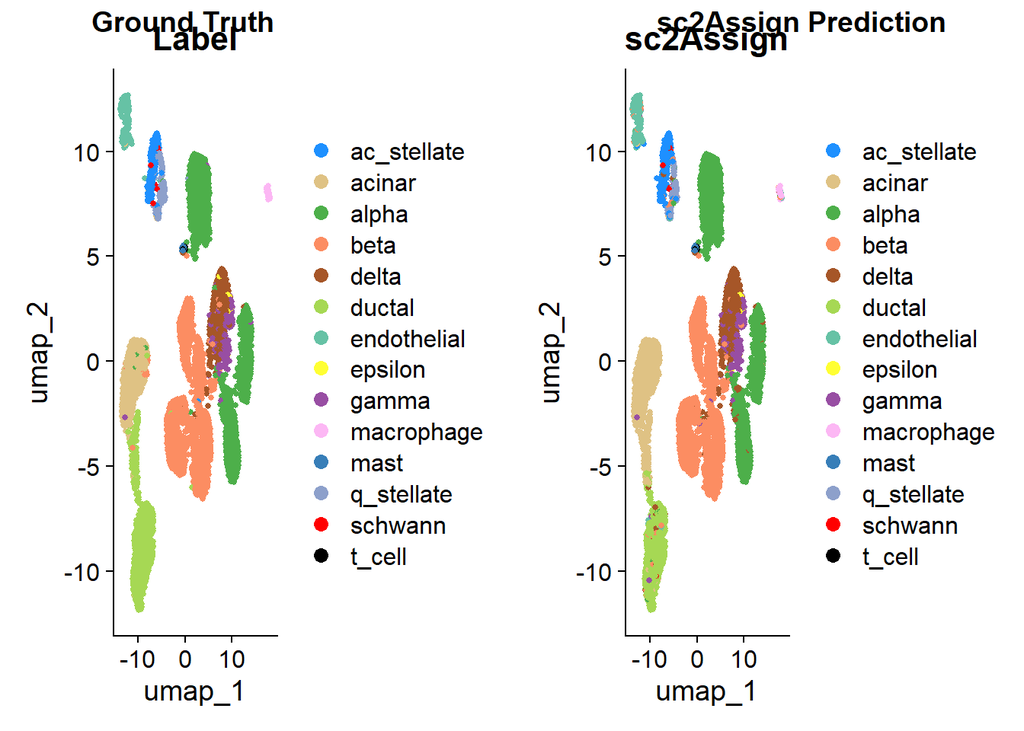

```r
# Assign sc2Assign predictions to Seurat object
Baron$sc2Assign <- pred_results$sc2Assign

# Plotting sc2Assign results
gg0 <- DimPlot(Baron, reduction = 'umap', group.by = 'sc2Assign',
        cols = colorCodes, label = FALSE, pt.size = 1)
# UMAP plot with cell labels
gg1 <- DimPlot(Baron, reduction = 'umap', label = FALSE, group.by = 'Label',
               pt.size = 1, cols = colorCodes, label.size = 4)
# Combine the plots side by side for comparison
 plot_grid(gg1, gg0, labels = c("Ground Truth", "sc2Assign Prediction"), ncol = 2)
```